# Marine Ecological Modelling Global Climate Change

Jorge Assis, PhD // Centre of Marine Sciences, University of Algarve

## Ecological Niche Models

## Model fitting

Model fitting is the heart of any SDM application. Many different algorithms are available to fit the relationship between occurrence records and environmental predictors.

### Generalised linear models

Generalised linear model (GLM) is a typical parametric regression algorithm that can fit linear, quadratic or higher polynomial terms and interactions between predictors.

```r
# load a vector defining global landmasses and crop to the Iberia Peninsula extent
world <- ne_countries(scale = "medium")
IberianExtent <- extent(-15, 5, 25, 46)
iberianLandMass <- crop(world, IberianExtent)

# read presence / absence datasets for an intertidal species
absences <- read.csv("Data/dataBases/Kelp-monitoring-absent.csv", sep = ";")
presences <- read.csv("Data/dataBases/Kelp-monitoring-presence.csv", sep = ";")
```

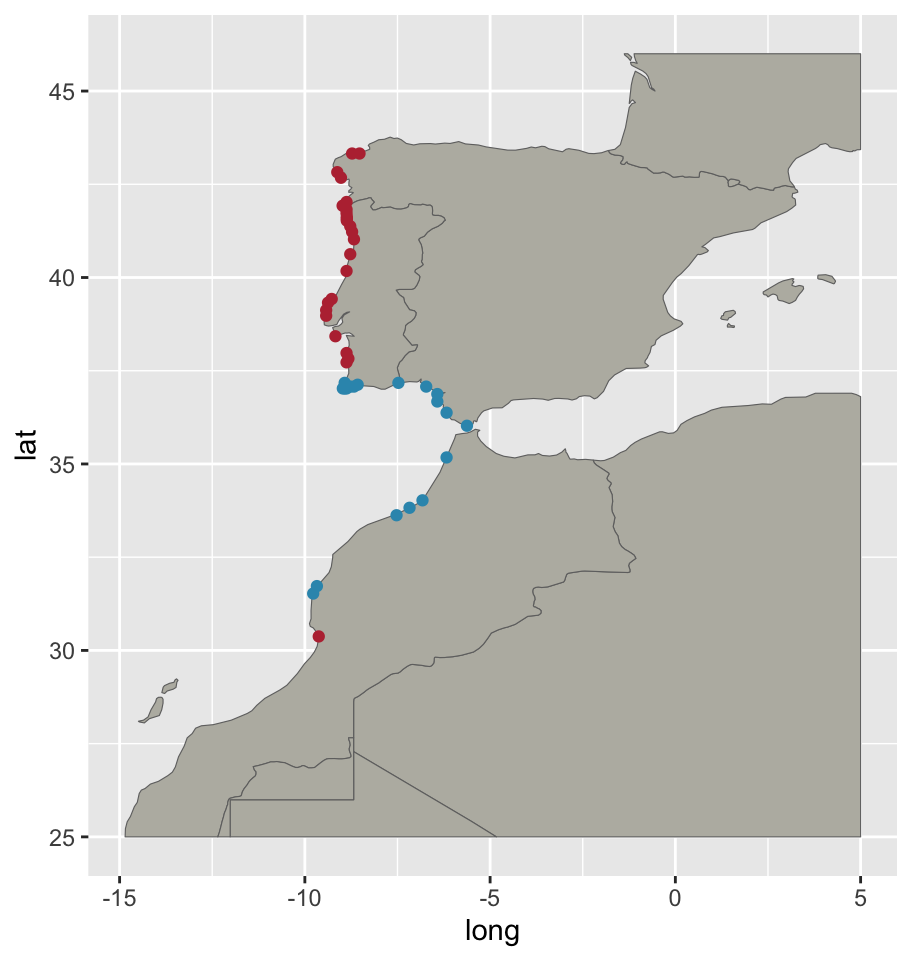

```r
# plot the distribution of records
ggplot() + geom_polygon(data = iberianLandMass, fill = "#B9B8B0", colour = "#707070", size = 0.2,
    aes(long, lat, group = group)) + geom_point(data = absences, aes(Lon, Lat), color = "#3296BA") +
    geom_point(data = presences, aes(Lon, Lat), color = "#BA323F")
```

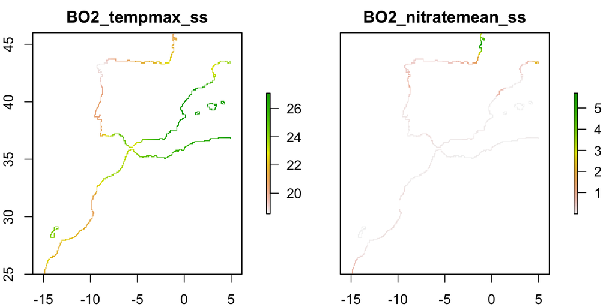

```r
# get environmental conditions
envConditions <- load_layers(c("BO2_tempmax_ss", "BO2_nitratemean_ss"))

# mask rasters to coastline regions (intertidal species) and crop to the region of interest
coastline <- raster("Data/rasterLayers/CoastLine.tif")
envConditions <- mask(envConditions, coastline)
envConditions <- crop(envConditions, IberianExtent)
plot(envConditions)
```

```r
# extract environmental values and make an object with all information to model
modelData <- prepareModelData(presences, absences, envConditions)

# fit a binomial GLM to the dataset
model <- trainGLM(modelData)

# predict the distribution with the GLM over a raster stack
map <- predict(envConditions, model, type = "response")

# transform to a data.frame for ggplot to read
map <- as.data.frame(map, xy = T, na.rm = T)
```

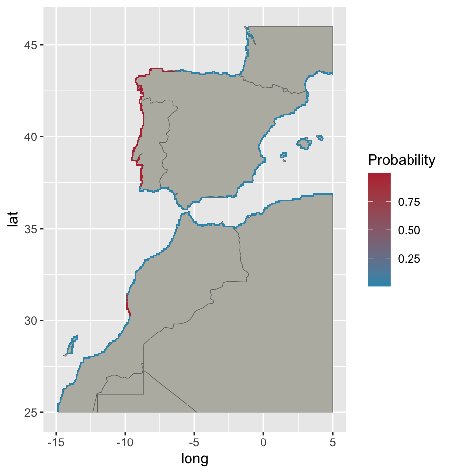

```r
# plot response of model
ggplot() + geom_polygon(data = iberianLandMass, fill = "#B9B8B0", colour = "#707070", size = 0.2,
    aes(long, lat, group = group)) + geom_tile(data = map, aes(x = x, y = y, fill = layer)) +
    scale_fill_gradient(low = "#3296BA", high = "#BA323F") + labs(fill = "Probability")
```

### Pseudo-absence data

If true absence data is not available, but one wants to fit an ecological niche model, pseudo-absence data can be generated.

```r
# generate pseudo-absences
pAbsences <- pseudoAbsences(envConditions, presences, n = 100)
head(pAbsences)
```

```
##            Lon      Lat
## 1  -3.29166667 36.70833
## 2  -5.29166667 36.20833
## 3 -13.87500000 28.79167
## 4  -8.79166667 37.04167
## 5  -0.04166667 38.95833
## 6   4.29166667 36.87500
```

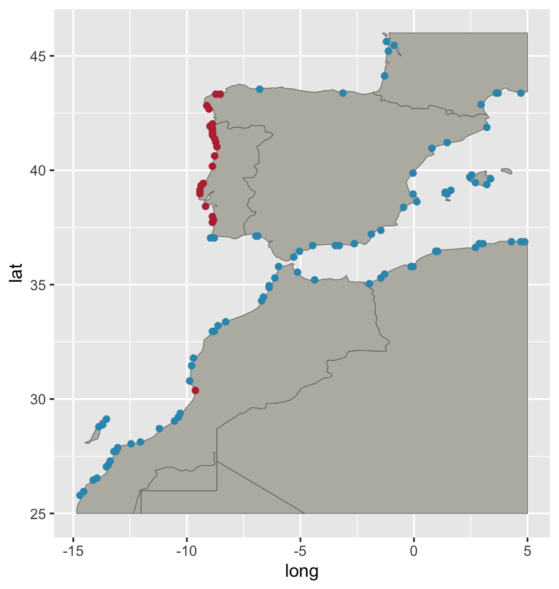

```r
# plot presences and pseudo-absences
ggplot() + geom_polygon(data = iberianLandMass, fill = "#B9B8B0", colour = "#707070", size = 0.2,
    aes(long, lat, group = group)) + geom_point(data = pAbsences, aes(Lon, Lat), color = "#3296BA") +
    geom_point(data = presences, aes(Lon, Lat), color = "#BA323F")
```

```r
# extract environmental values and make an object with all information to model
modelData <- prepareModelData(presences, pAbsences, envConditions)

# fit a binomial GLM to the dataset
model <- trainGLM(modelData)

# predict the distribution with the GLM over a raster stack
map <- predict(envConditions, model, type = "response")

# transform to a data.frame for ggplot to read
map <- as.data.frame(map, xy = T, na.rm = T)
```

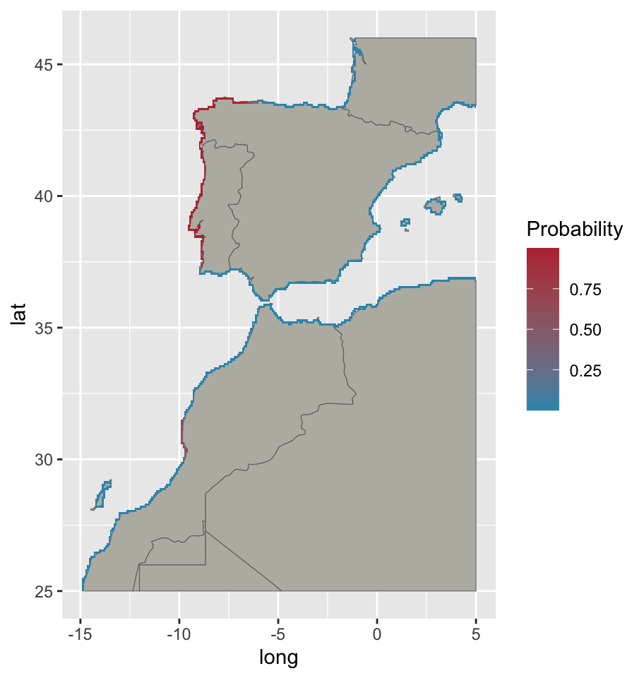

```r
# plot response of model
ggplot() + geom_polygon(data = iberianLandMass, fill = "#B9B8B0", colour = "#707070", size = 0.2,
    aes(long, lat, group = group)) + geom_tile(data = map, aes(x = x, y = y, fill = layer)) +
    scale_fill_gradient(low = "#3296BA", high = "#BA323F") + labs(fill = "Probability")
```

### Maximum Entropy

Maxent only uses presence data and the algorithm compares the locations of where a species has been found to all the environments that are available in the study region.

```r
# load a presence dataset for a deep coral
presences <- read.csv("Data/dataBases/Paramuricea_clavata.csv", sep = ";")
presences <- presences[, c("Lon", "Lat")]

# load layers of temperatures, oxygen and productivity
envConditions <- load_layers(c("BO2_tempmin_bdmean", "BO2_tempmax_bdmean", "BO2_dissoxmean_bdmean",
    "BO2_ppmean_bdmean"))

# crop layers to the European extent
europeanExtent <- extent(-15, 40, 25, 50)
envConditions <- crop(envConditions, europeanExtent)
```

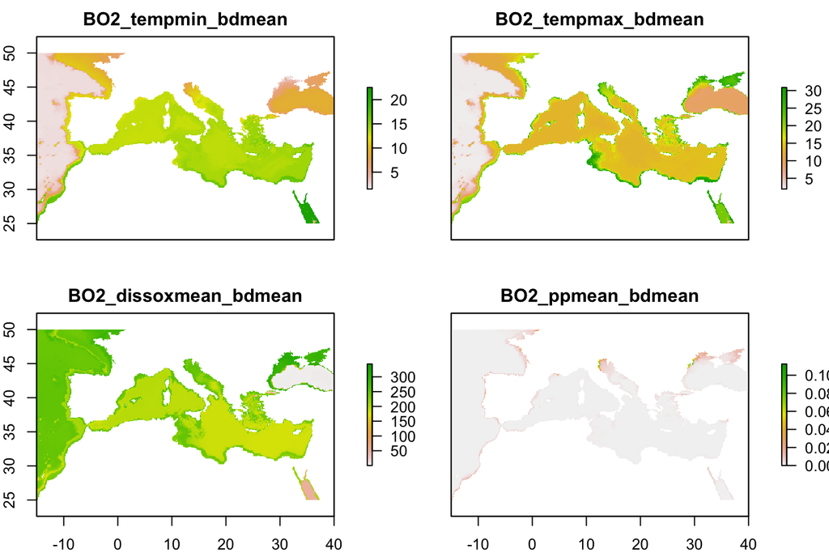

```r
# plot environmental layers
plot(envConditions)
```

```r
# generate background information
background <- backgroundInformation(envConditions, n = 10000)

# extract environmental values and make a data.frame with PA information
modelData <- prepareModelData(presences, background, envConditions)

# fit a Maxent model to the dataset
model <- train("Maxnet", modelData)

# predict with Maxent to raster stack
map <- predict(model, envConditions, type = "logistic")
```

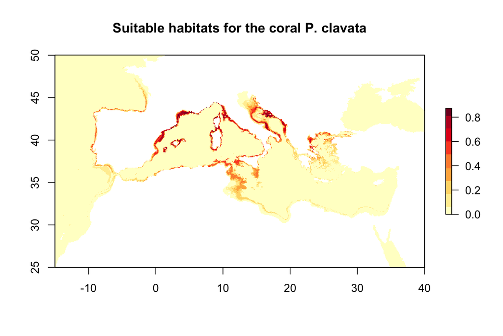

```r
# plot prediction of suitable habitats
plot(map, col = brewer.pal(n = 11, name = "YlOrRd"), main = "Suitable habitats for the coral P. clavata")
```

### Challenge 6.1

The main objetive of this challenge is to **fit** a MaxEnt model to your own occurrence and environmental data.

**Packages, data and functions to accomplish the challenge:**

source(“sourceFunctions.R”)  
list_layers(datasets = “Bio-ORACLE”)  
View()  
load_layers()  
extent(object)  
crop(object)  
backgroundInformation()  
prepareModelData()  
train()  
predict()  
plot()

## Model transferability

Model transferability is the process of transferring a model to a new dataset.

### Temporal transferability

Temporal transferability is the task of predicting to a distinct time than where the model was trained.

```r
# load a presence dataset for deep coral
presences <- read.csv("Data/dataBases/Paramuricea_clavata.csv", sep = ";")
presences <- presences[, c("Lon", "Lat")]

# load layers of sea surface temperatures
envlCondPresent <- load_layers(c("BO2_tempmin_bdmean", "BO2_tempmax_bdmean"))
envCondRCP26 <- load_layers(c("BO2_RCP26_2100_tempmin_bdmean", "BO2_RCP26_2100_tempmax_bdmean"))
```

Predictor layers must have the same name for proper transferability.

```r
# compare layer names
names(envlCondPresent)
```

```
## [1] "BO2_tempmin_bdmean" "BO2_tempmax_bdmean"
```

```r
names(envCondRCP26)
```

```
## [1] "BO2_RCP26_2100_tempmin_bdmean" "BO2_RCP26_2100_tempmax_bdmean"
```

```r
# change layer names for them to match
names(envCondRCP26) <- c("BO2_tempmin_bdmean", "BO2_tempmax_bdmean")

# crop layers to the European extent
europeanExtent <- extent(-15, 40, 25, 50)
envlCondPresent <- crop(envlCondPresent, europeanExtent)
envCondRCP26 <- crop(envCondRCP26, europeanExtent)
```

```r
# generate background information
background <- backgroundInformation(envlCondPresent, n = 10000)

# extract environmental values and make a data.frame with PA information
modelData <- prepareModelData(presences, background, envlCondPresent)

# fit a Maxent model to the dataset
model <- train("Maxnet", modelData, folds = NULL)

# predict with Maxent to the different time periods
map <- predict(model, envlCondPresent, type = c("logistic"))
mapRCP26 <- predict(model, envCondRCP26, type = c("logistic"))
```

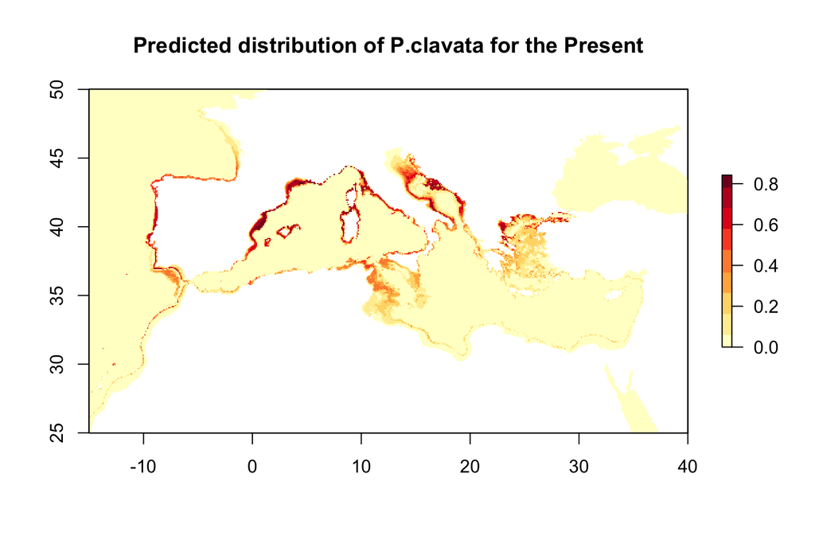

```r
# plot prediction
plot(map, main = "Predicted distribution of P.clavata for the Present", col = brewer.pal(n = 11,
    name = "YlOrRd"))
```

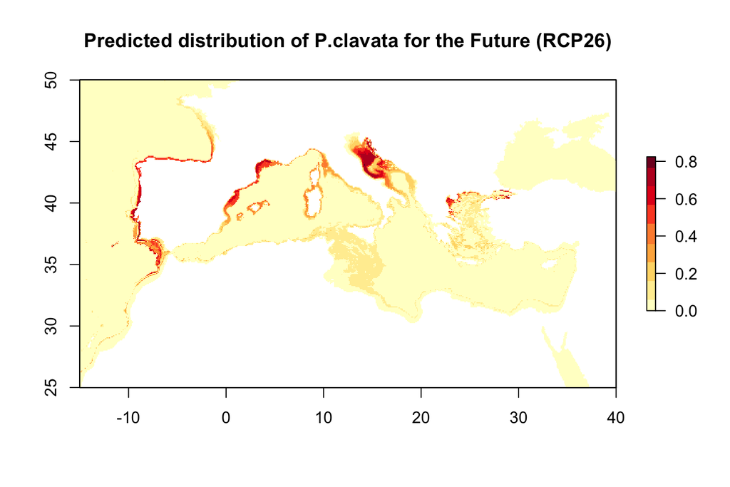

```r
# plot projection
plot(mapRCP26, main = "Predicted distribution of P.clavata for the Future (RCP26)", col = brewer.pal(n = 11,
    name = "YlOrRd"))
```

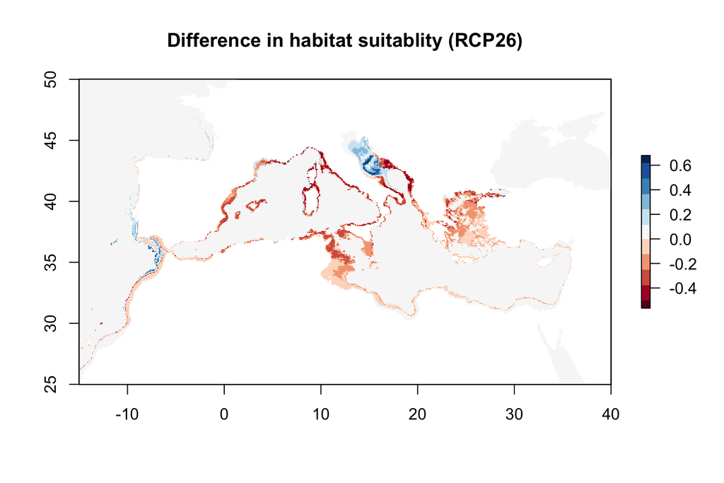

```r
# plot difference in habitat suitability
differenceRCP26 <- mapRCP26 - map
plot(differenceRCP26, main = "Difference in habitat suitablity (RCP26)", col = brewer.pal(n = 11,
    name = "RdBu"))
```

### Challenge 6.2

The main objetive of this challenge is to **fit** a MaxEnt model to your own occurrence and environmental data and transfer the model to different climate conditions.

**Packages, data and functions to accomplish the challenge:**

source(“sourceFunctions.R”)  
list_layers(datasets = “Bio-ORACLE”)  
list_layers_future(datasets = “Bio-ORACLE”)  
View()  
load_layers()  
extent(object)  
crop(object)  
backgroundInformation()  
prepareModelData()  
train()  
predict()  
plot()

### Spatial transferability

Spatial transferability is the task of predicting to a distinct region than where the model was trained.

```r
# load a presence dataset for an invasive species
presences <- getOccurrencesGBIF("Undaria pinnatifida")
presences <- presences[, c("Lon", "Lat")]

# load layers of light, sea surface temperatures and nutrients
envConditions <- load_layers(c("BO2_lightbotmean_bdmean", "BO2_tempmin_bdmean", "BO2_tempmax_bdmean",
    "BO2_nitratemean_bdmean"))

# crop layers to the native extent
nativeExtent <- extent(115, 155, 20, 50)
envConditionsNative <- crop(envConditions, nativeExtent)

# crop layers to the Invasive European extent
europeanExtent <- extent(-15, 40, 25, 75)
envConditionsEurope <- crop(envConditions, europeanExtent)
```

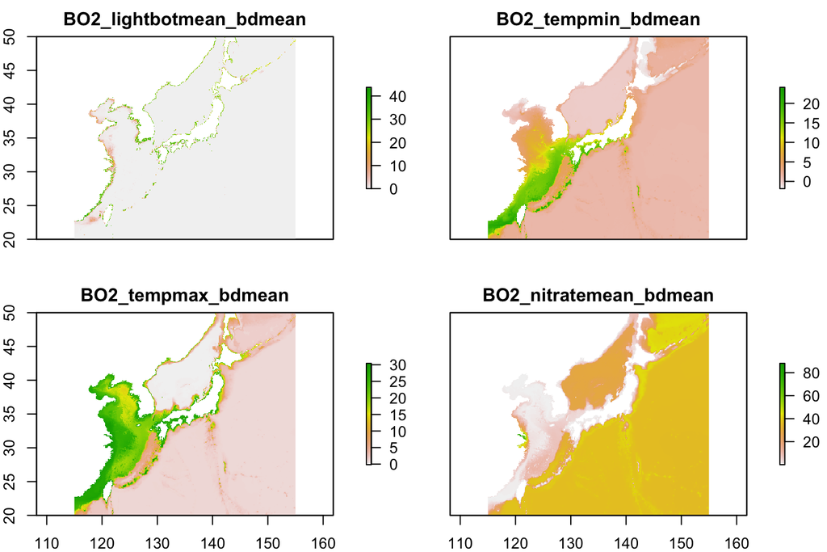

```r
# Plot environmental conditions of the native range
plot(envConditionsNative)
```

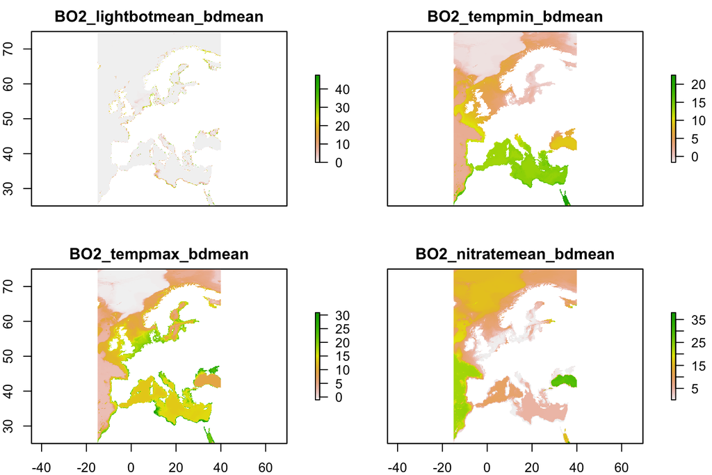

```r
# Plot environmental conditions of the invasive range
plot(envConditionsEurope)
```

```r
# generate background information
background <- backgroundInformation(envConditionsNative, n = 10000)

# extract environmental values and make a data.frame with PA information
modelData <- prepareModelData(presences, background, envConditionsNative)

# fit a Maxent model to the dataset
model <- train("Maxnet", modelData, folds = NULL)

# predict with Maxent to the different regions
mapNative <- predict(model, envConditionsNative, type = c("logistic"))
mapEurope <- predict(model, envConditionsEurope, type = c("logistic"))
```

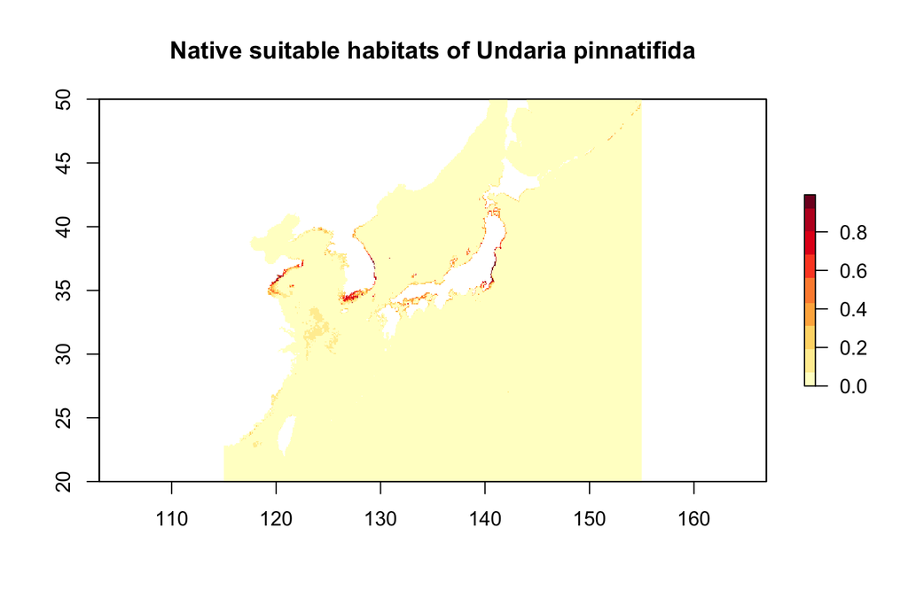

```r
# plot suitable habitats for native extent
plot(mapNative, main = "Native suitable habitats of Undaria pinnatifida", col = brewer.pal(n = 11,
    name = "YlOrRd"))
```

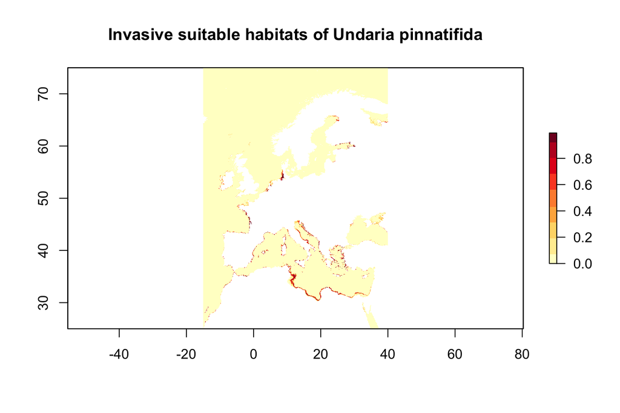

```r
# plot suitable habitats for invasive extent
plot(mapEurope, main = "Invasive suitable habitats of Undaria pinnatifida", col = brewer.pal(n = 11,
    name = "YlOrRd"))
```

### Challenge 6.3

The main objetive of this challenge is to **fit** a MaxEnt model to your own occurrence and environmental data and transfer the model to a different geographic regions

**Packages, data and functions to accomplish the challenge:**

source(“sourceFunctions.R”)  
list_layers(datasets = “Bio-ORACLE”)  
View()  
load_layers()  
extent(object)  
crop(object)  
backgroundInformation()  
prepareModelData()  
train()  
predict()  
plot()

## References

Global change impacts on biodiversity. Available at: https://damariszurell.github.io/HU-GCIB

Copyright (c) Earth Lab. Available at: https://www.earthdatascience.org.

Open Science for Synthesis: Gulf Research Program Workshop. Available at: https://github.com/NCEAS/oss-lessons

Gimond, M. (2019) Intro to GIS and Spatial Analysis. Available at: https://mgimond.github.io/Spatial/